# STA 380, Part 2: Exercises 1

Sam Malcolm

8/6/2018

## STA 380, Part 2: Exercises 1

```r
library(ggplot2)
set.seed(33)
```

#### Probability practice

##### Part A.

.71 of people who are truthful clickers answered Yes.

```r
p = (.65 - (.5*.3))/.7
p
```

```
## [1] 0.7142857
```

##### Part B.

###### Suppose someone tests positive. What is the probability that they have the disease? In light of this calculation, do you envision any problems in implementing a universal testing policy for the disease?

The probability that they have the disease is 19.88824%. This means that approximately 80% of the positive results will be false positives. This is not a reliable test, and those who receive false positives would have to incur unnecessary medical costs and, potentially, treatment.

```r
PPV = ((0.993)*(0.000025)/((0.993)*(0.000025)+(1-0.9999)*(1-0.000025))*100)
PPV
```

```
## [1] 19.88824
```

### Part 2: Exploratory Analysis

Overall, we think it’s a solid first step in an analysis. However, we question how he made certain decisions, believe he may have taken too vague of an approach, and ultimately think his conclusion is flawed.

For example, he arbitrarily removes buildings with very low occupancy rates because they “might have something weird going on with them” but still chooses to evaluate his decision based on the median, effectively discounting outliers twice.

He is correct that the mean and median rents of Green buildings tend to be higher than non-Green buildings overall. This appears to maintain when comparing the rents of Green buildings only to those in their cluster. However, there are still a significant number of occurrences where a Green building charges less respectively for rent.

```r
green <- read.csv(file="greenbuildings.csv", header=TRUE)

# Extract the buildings with green ratings + non-green ratings
green_only= subset(green, green_rating==1)
non_green = subset(green, green_rating==0)

mean(green_only$Rent)
```

```
## [1] 30.01603
```

```r
mean(non_green$Rent)
```

```
## [1] 28.26678
```

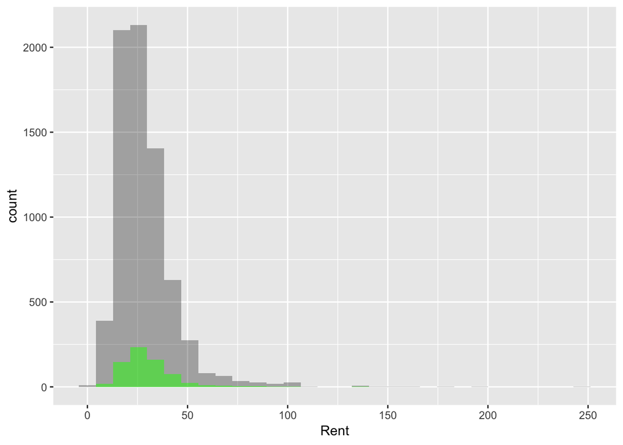

```r
ggplot() +
  geom_histogram(data=non_green, aes(Rent, fill = I('Black'), alpha = I(.3))) +
  geom_histogram(data=green_only, aes(Rent, fill = I('Green'), alpha = I(.5)))
```

With this in mind, if you were to plan to build in bulk - say 100 buildings - you might have a better chance of seeing a return on investment with Green certification as rents regressed toward the mean. However, for just 1 building, we can’t confidently say that you will be able to charge a premium.

To show this, we can take a few different perspectives. First, we’ll look at overall correlation between variables.

```r
#Correlation - 'Green' has only a .03 correlation with 'Rent'
corr_rent = cor(green$Rent, green$green_rating)
corr_rent
```

```
## [1] 0.03266587
```

‘Green’ has only a .03 correlation with ‘Rent.’ Immediately we can see that this relationship might not be as straightforward as he proposed.

Perhaps it would be more useful to compare the rent of a Green building with the mean rent in its cluster.

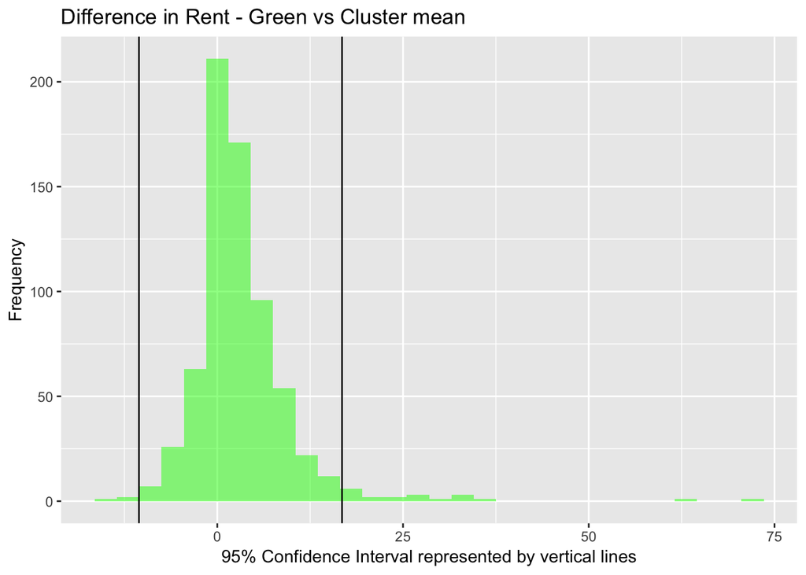

```r
# How does the rent of a green building compare with those in its cluster?
cluster_diff = green[green$green_rating == 1,]$Rent - green[green$green_rating == 1,]$cluster_rent

mean_diff = mean(cluster_diff)
median_diff = median(cluster_diff)

green_only$cluster_diff = green_only$Rent - green_only$cluster_rent

ggplot() +
  geom_histogram(data=green_only, aes(cluster_diff, fill = I('Green'), alpha = I(.5))) +
  geom_vline(aes(xintercept = mean(cluster_diff) + 2*sd(cluster_diff)), colour="black") +
  geom_vline(aes(xintercept = mean(cluster_diff) - 2*sd(cluster_diff)), colour="black") +
  ggtitle("Difference in Rent - Green vs Cluster mean") +
  xlab("95% Confidence Interval represented by vertical lines") +
  ylab("Frequency")
```

We observe that the mean difference between a Green building and those in its cluster is about $3.12 while the median is $2.10. In either case, it is similar to what the staffmember had found. However, we do observe a couple outliers. Even with those, the 95% confidence interval shows that there is a significant amount of Green buildings whose rent was less than the mean of its cluster.